# Project

Source: https://www.kaggle.com/datasets/uom190346a/disease-symptoms-and-patient-profile-dataset

Description: Unveil the mysteries of diseases with our Comprehensive Disease Symptom and Patient Profile Dataset. This captivating dataset offers a treasure trove of information, revealing the fascinating connections between symptoms, demographics, and health indicators. Delve into the rich tapestry of fever, cough, fatigue, and difficulty breathing, intertwined with age, gender, blood pressure, and cholesterol levels. Whether you're a medical researcher, healthcare professional, or data enthusiast, this dataset holds the key to unlocking profound insights. Explore the hidden patterns, uncover unique symptom profiles, and embark on a captivating journey through the world of medical conditions. Get ready to revolutionize healthcare understanding with our dataset.

Variables(n = 10): -'Disease' Nominal -'Fever' Nominal -'Cough' Nominal -'Fatigue' Nominal -'Difficulty Breathing': Nominal -'Age': Continuous -'Gender': Nominal -'Blood Pressure': Ordinal -'Cholestrol Level': Ordinal -'Outcome' Nominal

```python
# imports
import pandas as pd
import numpy as np
import seaborn as sns
import matplotlib.pyplot as plt
%matplotlib inline
import scipy.stats as stats
from scipy.stats import skew, norm, probplot, boxcox, f_oneway

import warnings
warnings.filterwarnings("ignore")
```

```python
df = pd.read_csv("disease_symptoms.csv")
```

```python
df.columns
```

```
Index(['Disease', 'Fever', 'Cough', 'Fatigue', 'Difficulty Breathing', 'Age',
       'Gender', 'Blood Pressure', 'Cholesterol Level', 'Outcome Variable'],
      dtype='object')
```

```python
df.shape
```

```
(349, 10)
```

```python
df.info()
```

```
<class 'pandas.core.frame.DataFrame'>
RangeIndex: 349 entries, 0 to 348
Data columns (total 10 columns):
 #   Column                Non-Null Count  Dtype
---  ------                --------------  -----
 0   Disease               349 non-null    object
 1   Fever                 349 non-null    object
 2   Cough                 349 non-null    object
 3   Fatigue               349 non-null    object
 4   Difficulty Breathing  349 non-null    object
 5   Age                   349 non-null    int64
 6   Gender                349 non-null    object
 7   Blood Pressure        349 non-null    object
 8   Cholesterol Level     349 non-null    object
 9   Outcome Variable      349 non-null    object
dtypes: int64(1), object(9)
memory usage: 27.4+ KB
```

```python
# Reducing number of decimals
pd.set_option('display.float_format', lambda x: '%.2f' % x)
df.describe().T
```

|  | count | mean | std | min | 25% | 50% | 75% | max |
| --- | --- | --- | --- | --- | --- | --- | --- | --- |
| Age | 349.00 | 46.32 | 13.09 | 19.00 | 35.00 | 45.00 | 55.00 | 90.00 |

```python
df["Outcome Variable"].value_counts()
```

```
Positive    186
Negative    163
Name: Outcome Variable, dtype: int64
```

```python
# Use flooring and capping method
def treat_outliers(df,col):
    Q1=df[col].quantile(0.25)
    Q3=df[col].quantile(0.75)
    IQR=Q3-Q1
    Lower_Whisker = Q1 - 1.5*IQR
    Upper_Whisker = Q3 + 1.5*IQR
    df[col] = np.clip(df[col], Lower_Whisker, Upper_Whisker)
    return df

def treat_outliers_all(df, col_list):
    for c in col_list:
        df = treat_outliers(df,c)
    return df
```

```python
numerical_col = df.select_dtypes(include=np.number).columns.tolist()
df = treat_outliers_all(df,numerical_col)
```

```python
df.std() # 1 SD
```

[output not shown]

```python
df.mean() #This ouput shows that the mean age is about 46 years old, which can also be seen from the boxplot below.

#There seem to be more patients with higher blood pressure and Cholesterol Levels
```

[output not shown]

[figure not shown]

```python
## RECALL...
# Outlier detection using boxplots

plt.figure(figsize=(20,30))

for i, variable in enumerate(df):
                     plt.subplot(5,4,i+1)
                     plt.boxplot(df[variable],whis=1.5)
                     plt.tight_layout()
                     plt.title(variable)

plt.show()
```

## Exploratory Data Analysis

[figure not shown]

```python
plt.figure(figsize=(10,6))
sns.set(font_scale=0.8)
plt.rcParams["axes.labelsize"] = 0.5
sns.heatmap(df.corr(), annot=True, cmap="coolwarm");
```

### Pearson's correlation seen as very low throughout most values

```python
! pip install phik
import phik
from phik import resources, report
```

```python
df.phik_matrix()
```

[output not shown]

[output not shown]

```python
from phik.report import plot_correlation_matrix
phik_overview = df.phik_matrix()
```

```
interval columns not set, guessing: ['Age']
```

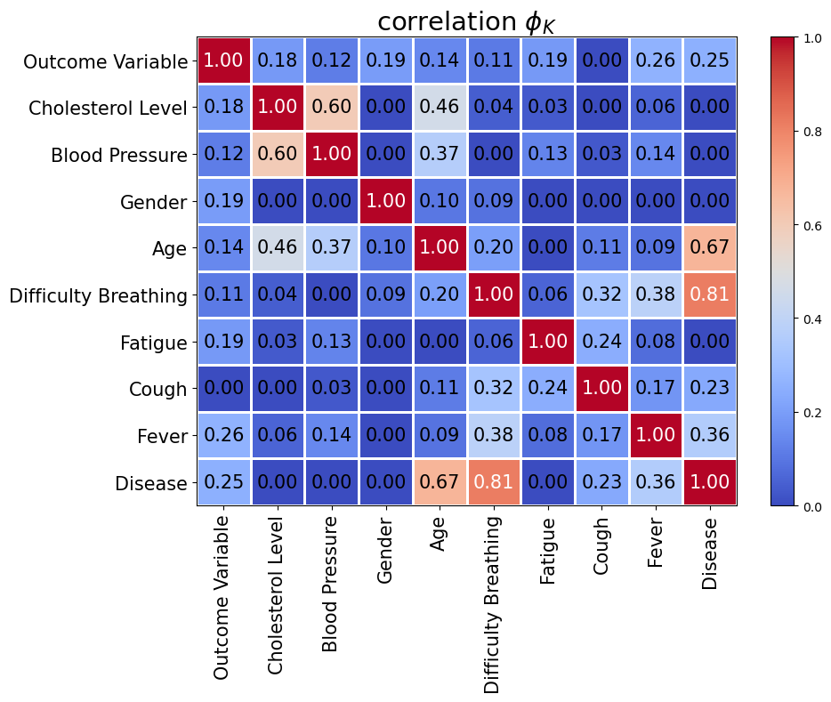

```python
plot_correlation_matrix(phik_overview.values,
                        x_labels=phik_overview.columns,
                        y_labels=phik_overview.index,
                        vmin=0, vmax=1, color_map="coolwarm",
                        title=r"correlation $\phi_K$",
                        fontsize_factor=1.5,
                        figsize=(10, 8))
plt.tight_layout()
```

### Phi-k correlation, showing fever and disease having the highest correlation with the Outcome Variable

```python
Q1 = df.quantile(.25)
Q3 = df.quantile(.75)
IQR_df = Q3-Q1
print(IQR_df)
```

[output not shown]

### The interquartile range of age is about 20 years

```python
df.mean()
```

[output not shown]

```python
df.std()
```

[output not shown]

### Mean of age is 46.3, with a standard deviation of about 13

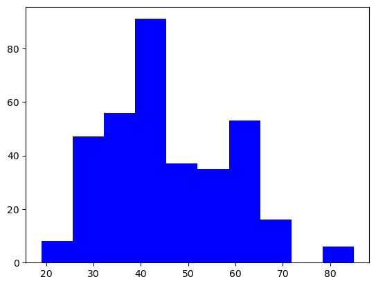

```python
# Histogram
plt.hist(df['Age'], color='b');
```

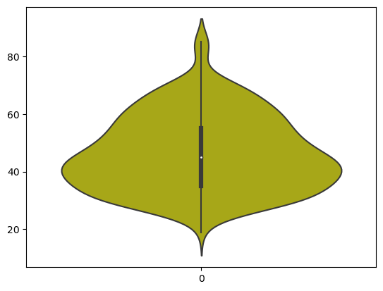

```python
#Violin plot
sns.violinplot(df['Age'],color='y');
```

### Age has a center of about 45

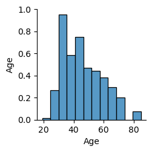

```python
sns.pairplot(df);
```

```python
def boxplot_histogram (feature, figsize=(10,7), bins = None):
    sns.set(font_scale=2)
    f2, (ax_box2, ax_hist2) = plt.subplots(nrows = 2,
                                           sharex = True,
                                           gridspec_kw = {"height_ratios": (.25, .75)},
                                           figsize = figsize
                                           )
    sns.boxplot(feature, ax=ax_box2, showmeans=True, color='red') # mean value will be noted
    sns.distplot(feature, kde=F, ax=ax_hist2, bins=bins) if bins else sns.distplot(feature, kde=False, ax=ax_hist2, fit=norm)
    ax_hist2.axvline(np.mean(feature), color='g', linestyle='--') # Add mean to the histogram
    ax_hist2.axvline(np.median(feature), color='black', linestyle='-') # Add median to the histogram
    plt.axvline(feature.mode()[0], color='r', linestyle='dashed', linewidth=1); #Add mode to the histogram
```

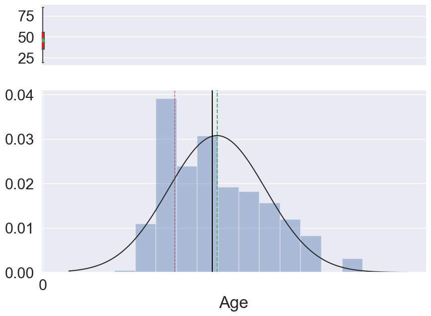

```python
boxplot_histogram(df.Age)
```

## Bivariate Analysis

In this section I also mapped the variables.

### The outcome is the dependent variable, and all of the other variables are independent variables, due to the fact that they are being used to predict the outcome.

```python
df.Fever
```

```
0      Yes
1       No
2       No
3      Yes
4      Yes
      ...
344    Yes
345    Yes
346    Yes
347    Yes
348    Yes
Name: Fever, Length: 349, dtype: object
```

```python
# Map 0's and 1's to Variables
df.Fever =df['Fever'].map({'No':0, 'Yes':1})
```

```python
df.Fever
```

```
0      1
1      0
2      0
3      1
4      1
      ..
344    1
345    1
346    1
347    1
348    1
Name: Fever, Length: 349, dtype: int64
```

```python
df.Cough = df['Cough'].map({'No':0, 'Yes':1})
```

```python
df.Cough
```

```
0      0
1      1
2      1
3      1
4      1
      ..
344    0
345    0
346    0
347    0
348    0
Name: Cough, Length: 349, dtype: int64
```

```python
df.Fatigue = df['Fatigue'].map({'No':0, 'Yes':1})
```

```python
df.Fatigue
```

```
0      1
1      1
2      1
3      0
4      0
      ..
344    1
345    1
346    1
347    1
348    1
Name: Fatigue, Length: 349, dtype: int64
```

```python
df.rename({'Difficulty Breathing':'DF_Breathing'}, axis=1, inplace=True)
```

```python
df.DF_Breathing = df['DF_Breathing'].map({'No':0, 'Yes':1})
```

```python
df.DF_Breathing
```

```
0      1
1      0
2      0
3      1
4      1
      ..
344    0
345    0
346    0
347    0
348    0
Name: DF_Breathing, Length: 349, dtype: int64
```

```python
df.Gender = df['Gender'].map({'Female':0, 'Male':1})
```

```python
df.Gender
```

```
0      0
1      0
2      0
3      1
4      1
      ..
344    0
345    1
346    1
347    0
348    0
Name: Gender, Length: 349, dtype: int64
```

```python
df.rename({'Blood Pressure':'BP'}, axis=1, inplace=True)
```

```python
df.BP = df['BP'].map({'Low':0, 'Normal':1, 'High': 2})
```

```python
df.BP
```

```
0      0
1      1
2      1
3      1
4      1
      ..
344    2
345    2
346    2
347    2
348    2
Name: BP, Length: 349, dtype: int64
```

```python
df.rename({'Cholesterol Level':'CL'}, axis=1, inplace=True)
```

```python
df.CL = df['CL'].map({'Low':0, 'Normal':1, 'High': 2})
```

```python
df.CL
```

```
0      1
1      1
2      1
3      1
4      1
      ..
344    2
345    2
346    2
347    2
348    2
Name: CL, Length: 349, dtype: int64
```

```python
#Renaming "Outcome Variable" to "Outcome"
df.rename({'Outcome Variable':'Outcome'}, axis=1, inplace=True)
```

```python
df.Outcome= df['Outcome'].map({'Negative':0, 'Positive':1})
```

```python
df.Outcome
```

```
0      1
1      0
2      0
3      1
4      1
      ..
344    1
345    1
346    1
347    1
348    1
Name: Outcome, Length: 349, dtype: int64
```

```python
from sklearn.preprocessing import LabelEncoder
le = LabelEncoder()
df['Disease'] = le.fit_transform(df['Disease'])

# print the mapping
for i, Disease in enumerate(le.classes_):
    print(f'{Disease} is represented by {i}')

#Credit: ChatGPT
```

```
Acne is represented by 0
Allergic Rhinitis is represented by 1
Alzheimer's Disease is represented by 2
Anemia is represented by 3
Anxiety Disorders is represented by 4
Appendicitis is represented by 5
Asthma is represented by 6
Atherosclerosis is represented by 7
Autism Spectrum Disorder (ASD) is represented by 8
Bipolar Disorder is represented by 9
Bladder Cancer is represented by 10
Brain Tumor is represented by 11
Breast Cancer is represented by 12
Bronchitis is represented by 13
Cataracts is represented by 14
Cerebral Palsy is represented by 15
Chickenpox is represented by 16
Cholecystitis is represented by 17
Cholera is represented by 18
Chronic Kidney Disease is represented by 19
Chronic Obstructive Pulmonary Disease (COPD) is represented by 20
Chronic Obstructive Pulmonary... is represented by 21
Cirrhosis is represented by 22
Colorectal Cancer is represented by 23
Common Cold is represented by 24
Conjunctivitis (Pink Eye) is represented by 25
Coronary Artery Disease is represented by 26
Crohn's Disease is represented by 27
Cystic Fibrosis is represented by 28
Dementia is represented by 29
Dengue Fever is represented by 30
Depression is represented by 31
Diabetes is represented by 32
Diverticulitis is represented by 33
Down Syndrome is represented by 34
Eating Disorders (Anorexia,... is represented by 35
Ebola Virus is represented by 36
Eczema is represented by 37
Endometriosis is represented by 38
Epilepsy is represented by 39
```

[output cut: 61 more lines]

```
Stroke is represented by 101
Systemic Lupus Erythematosus... is represented by 102
Testicular Cancer is represented by 103
Tetanus is represented by 104
Thyroid Cancer is represented by 105
Tonsillitis is represented by 106
Tourette Syndrome is represented by 107
Tuberculosis is represented by 108
Turner Syndrome is represented by 109
Typhoid Fever is represented by 110
Ulcerative Colitis is represented by 111
Urinary Tract Infection is represented by 112
Urinary Tract Infection (UTI) is represented by 113
Williams Syndrome is represented by 114
Zika Virus is represented by 115
```

```python
# Map numbers to Disease
#df.Disease =df['Disease'].map({'Asthma':0, 'Stroke':1})
from sklearn.preprocessing import LabelEncoder

# assume df is your DataFrame and "disease" is the column with diseases
le = LabelEncoder()
df['Disease'] = le.fit_transform(df['Disease'])
#Credit: ChatGPT
```

```python
df.Disease
```

```
0       56
1       24
2       37
3        6
4        6
      ...
344    101
345    101
346    101
347    101
348    101
Name: Disease, Length: 349, dtype: int64
```

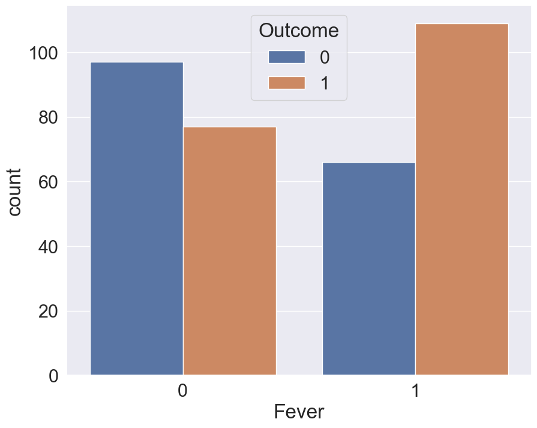

```python
plt.figure(figsize=(10,8))
sns.countplot(data=df, x='Fever', hue='Outcome');
```

### From the comparison above, it appears as though when there was no fever, the disease was more negatively diagnosed, but when there was a fever, the disease was more positively diagnosed

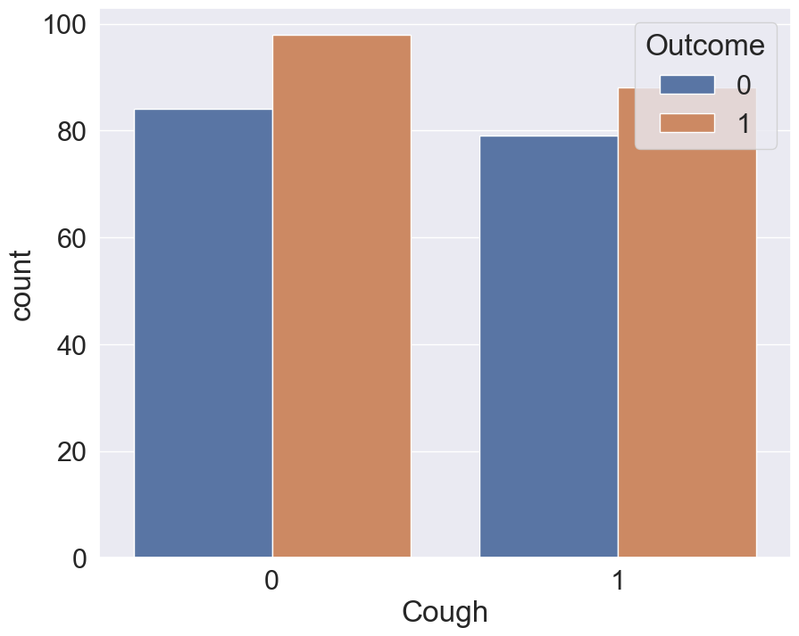

```python
plt.figure(figsize=(10,8))
sns.countplot(data=df, x='Cough', hue='Outcome');
```

### The outcome was more positive regardless of if there was a cough or not. However it was more positive if there was no cough.

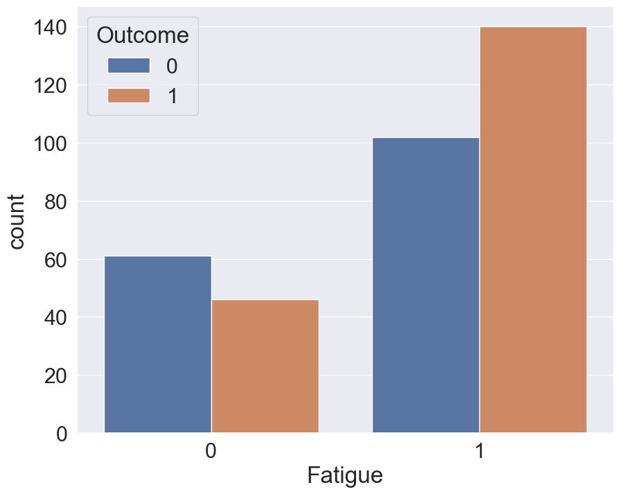

```python
plt.figure(figsize=(10,8))
sns.countplot(data=df, x='Fatigue', hue='Outcome');
```

### No fatigue led to more negative outcomes, but there was more positive outcome when there was fatigue

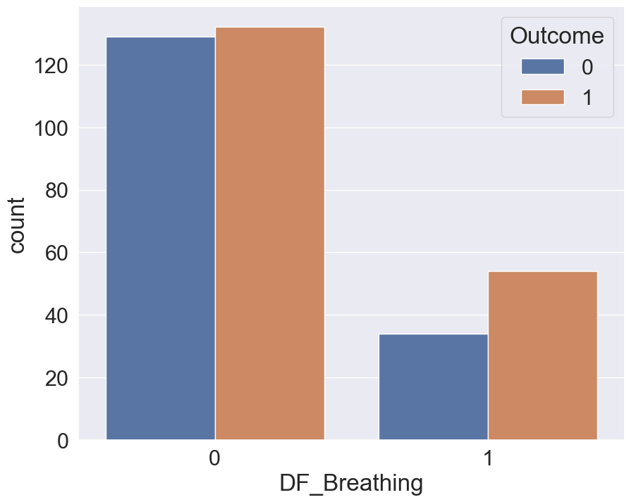

```python
plt.figure(figsize=(10,8))
sns.countplot(data=df, x='DF_Breathing', hue='Outcome');
```

### Less difficulty breathing gave better diagnoses

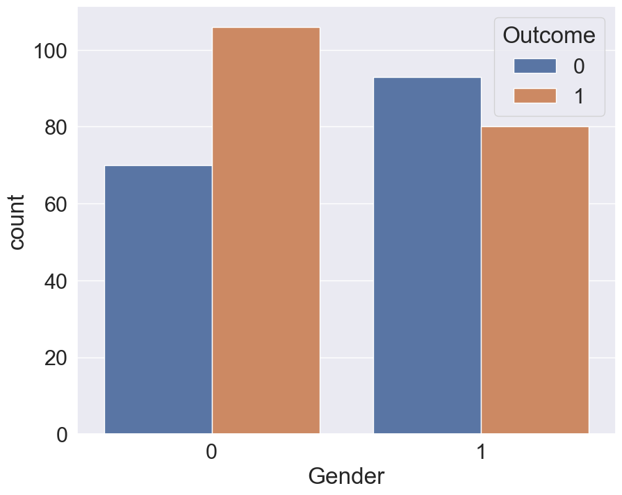

```python
plt.figure(figsize=(10,8))
sns.countplot(data=df, x='Gender', hue='Outcome');
```

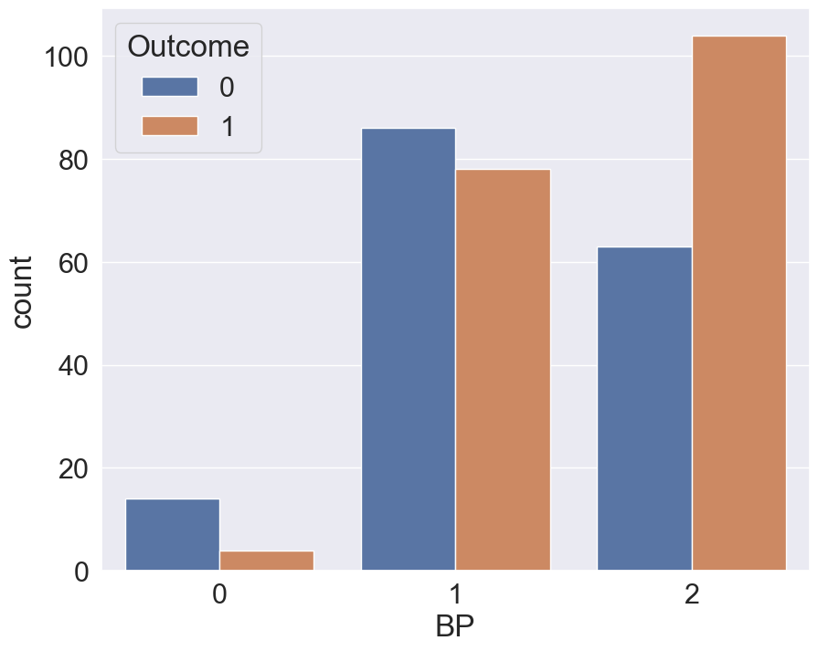

```python
plt.figure(figsize=(10,8))
sns.countplot(data=df, x='BP', hue='Outcome');
```

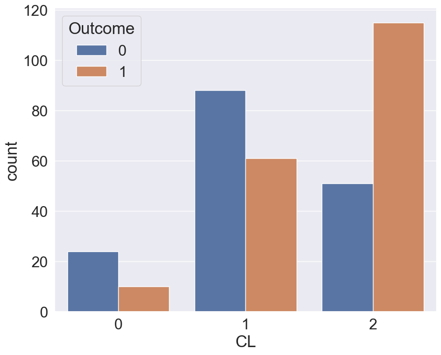

```python
plt.figure(figsize=(10,8))
sns.countplot(data=df, x='CL', hue='Outcome');
```